# Analysis and visualization

2026-01-08

This is an R Markdown document for easy access to and recreation of the figures for the manuscript “Measuring the health benefits, costs, and cost-effectiveness of antimicrobial-resistant gonorrhea surveillance in the United States”, currently in revision at *Lancet Public Health Americas.*

# Figure 1

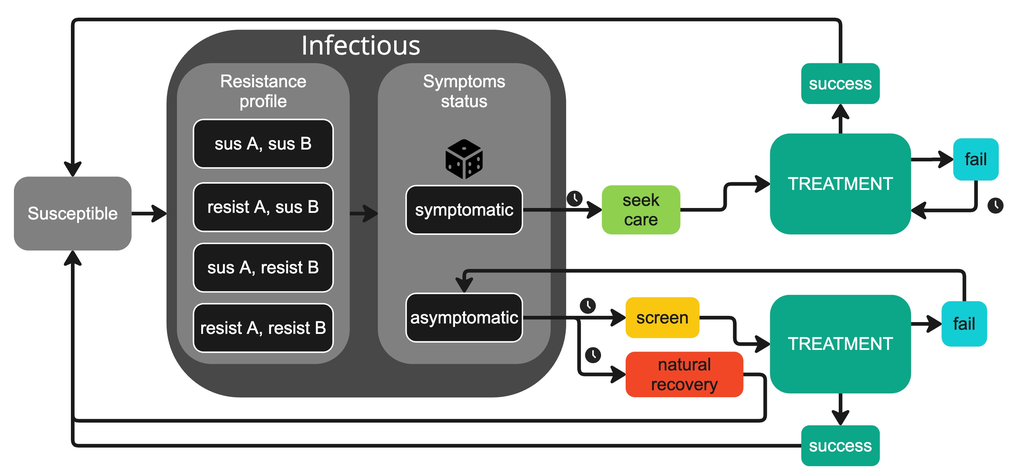

**Figure 1.**

# Figure 2

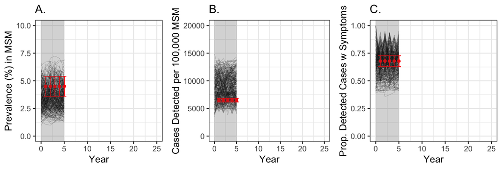

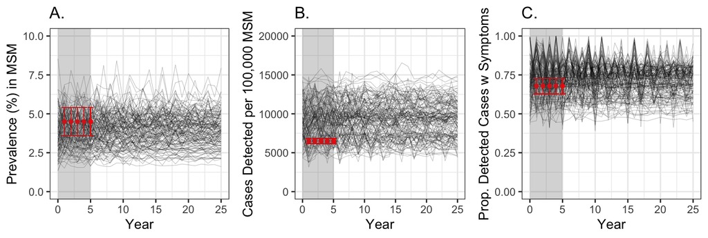

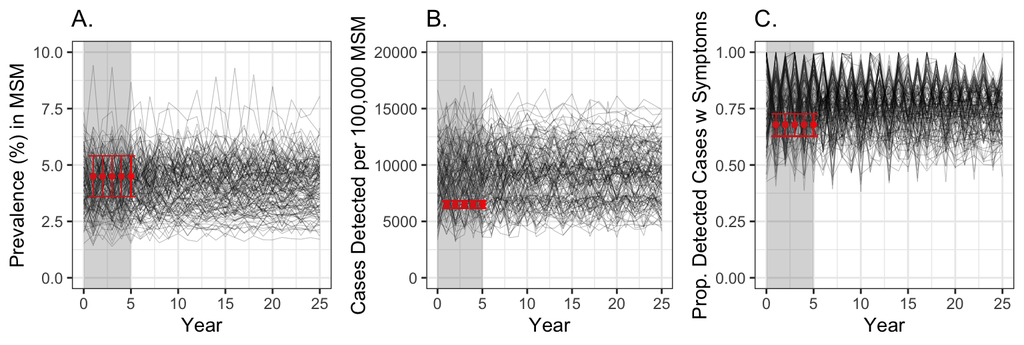

|  | Calibration Target | Posterior estimate (mean) | Posterior 95% CI | Posterior 50% CI | Target Within 95% CI? | Target Within 50% CI? | Absolute Error | Relative Error (%) | Z-score | Posterior Predictive P-value | 95% CI Overlap |
| --- | --- | --- | --- | --- | --- | --- | --- | --- | --- | --- | --- |
| Prevalence | 4.50 | 3.96 | (2.08, 6.10) | (3.15, 4.68) | TRUE | TRUE | 0.54 | 12.10 | 0.51 | 0.31 | 1 |
| Detected cases | 6508.00 | 9299.42 | (4877.00, 14037.48) | (7379.25, 10978.25) | TRUE | FALSE | 2791.42 | 42.89 | -1.15 | 0.86 | 1 |
| Proportion detected cases symptomatic | 0.68 | 0.71 | (0.50, 0.94) | (0.63, 0.78) | TRUE | TRUE | 0.03 | 4.44 | -0.27 | 0.63 | 1 |

# Figure 3

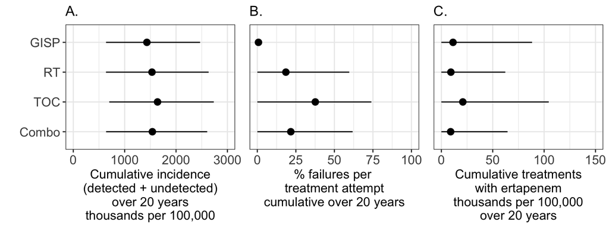

# Figure 4

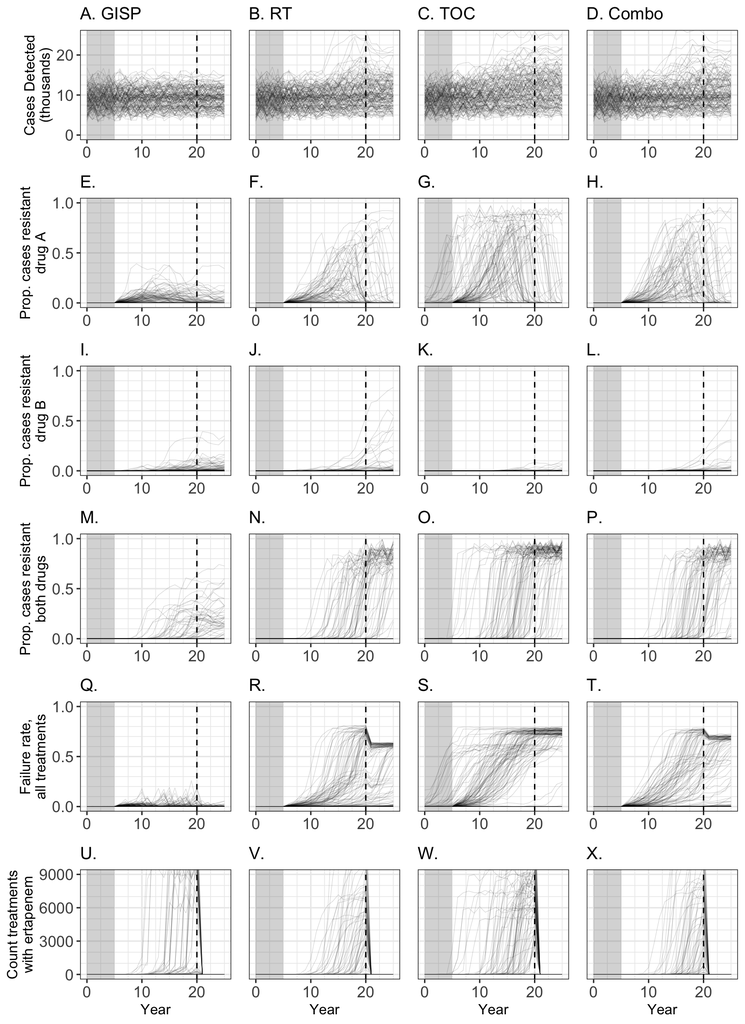

# Figure 5

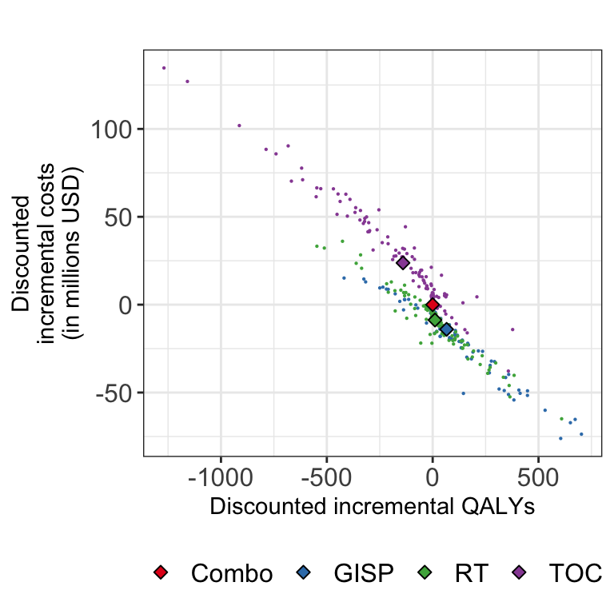

|  | GISP | Randomized Treatment (RT) | Test of Cure (TOC) | Combo |
| --- | --- | --- | --- | --- |
| Incidence Mean | 1432582.64 | 1531827.16 | 1639650.59 | 1539373.43 |
| Incidence Quantiles | 637530.8, 2468361.72 | 636783.62, 2634151.17 | 700157.68, 2734676.87 | 638336.88, 2606963.22 |
| resistance Mean | 95524.66 | 416215.81 | 795104.72 | 435908.34 |
| Resistance Quantiles | 254.18, 366334.77 | 376.18, 1600633.95 | 254.32, 2473411.52 | 344.65, 1640354.47 |
| Failure Mean | 0.74 | 18.51 | 37.62 | 21.73 |
| Failure Quantiles | 0.02, 2.51 | 0.03, 59.65 | 0.02, 73.98 | 0.03, 61.85 |
| Ertapenem Mean | 11346.36 | 9268.48 | 20887.66 | 9045.49 |
| Ertapenem Quantiles | 0, 88296.65 | 0, 62218.12 | 0, 104513.17 | 0, 64443.1 |

```
## [1] 57
```

```
## [1] 0.4253731
```

```
## [1] 56
```

```
## [1] 0.4179104
```

```
## [1] 71
```

```
## [1] 0.5298507
```

```
## [1] 32
```

```
## [1] 0.238806
```

```
## [1] 0
```

```
## [1] 0
```

```
## [1] 11
```

```
## [1] 0.08208955
```

```
## [1] 6
```

```
## [1] 0.04477612
```

```
## [1] 35
```

```
## [1] 0.261194
```

|  | GISP | Randomized Treatment (RT) | Test of Cure (TOC) | Combo |
| --- | --- | --- | --- | --- |
| Cost Mean | 42.63 | 47.91 | 80.43 | 56.66 |
| Cost Quantiles | 23.95, 69.28 | 23.37, 93.08 | 30.71, 163.22 | 27.87, 117.22 |
| QALY Mean | 410.99 | 465.93 | 617.03 | 476.85 |
| QALY Quantiles | 170.05, 820.27 | 168.29, 1111.2 | 181.78, 1517.23 | 168.83, 1151.86 |

# Supplement

Validation: results of the partial-rank correlation coefficient (PRCC) analysis

Prevalence PRCC

[output not shown]

Incidence PRCC

[output not shown]

Symptomatic Proportion PRCC

[output not shown]

Costs PRCC

[output not shown]

QALYs PRCC

[output not shown]

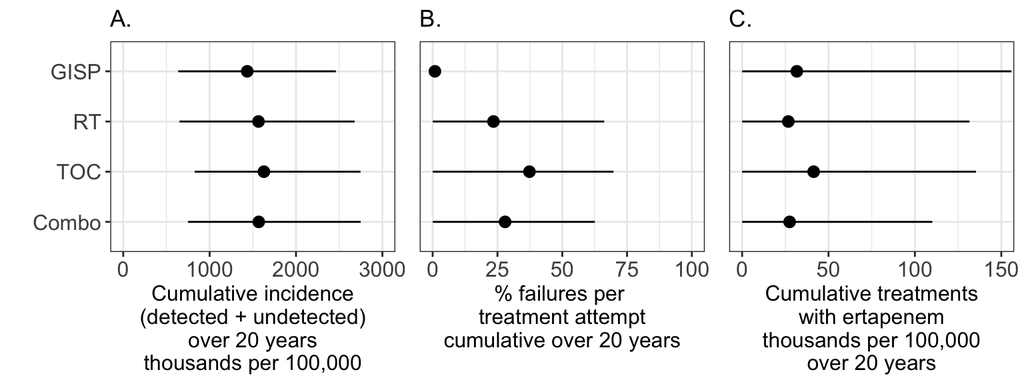

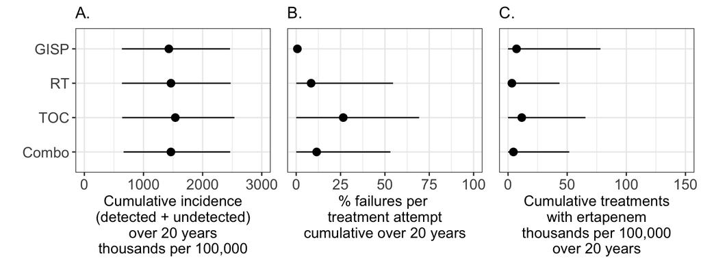

Figure. Summary plot when fitness costs were 1% for both strain resistant to drug A and strain resistant to drug B.

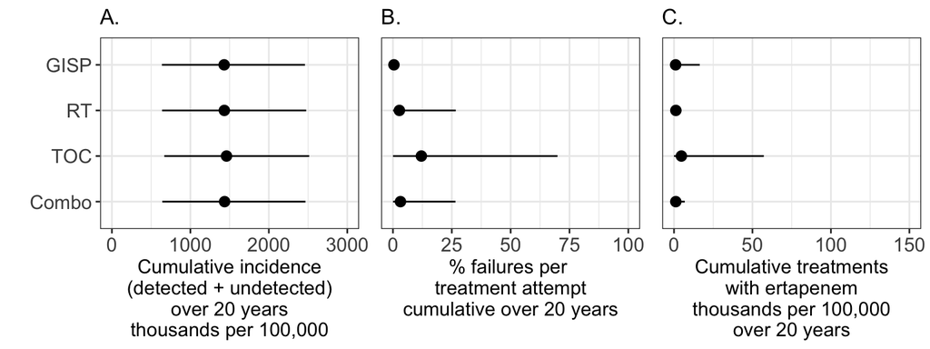

Figure. Summary plot when fitness costs were 2.5% for both strain resistant to drug A and strain resistant to drug B.

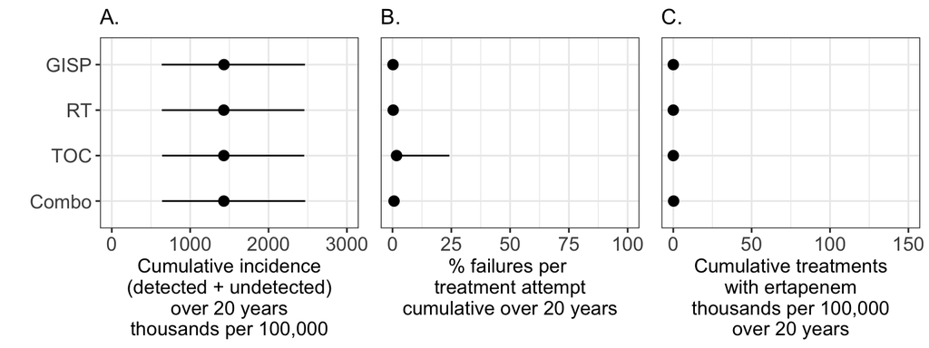

Figure. Summary plot when fitness costs were 5% for both strain resistant to drug A and strain resistant to drug B.

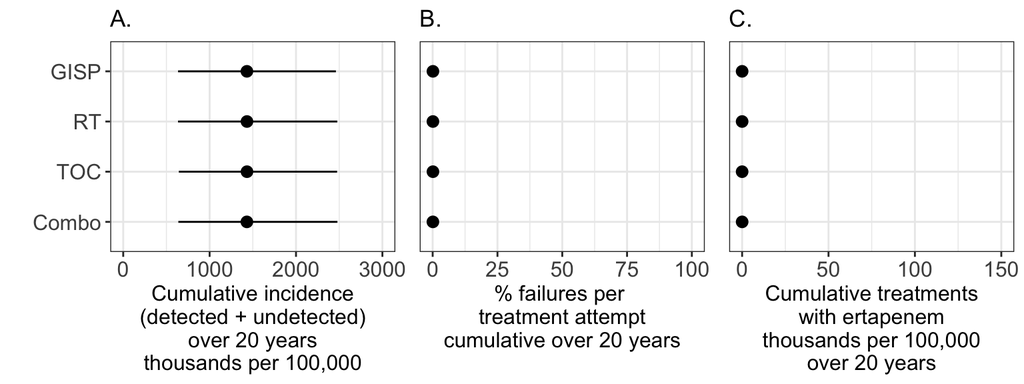

Figure. Summary plot when fitness costs were 10% for both strain resistant to drug A and strain resistant to drug B.

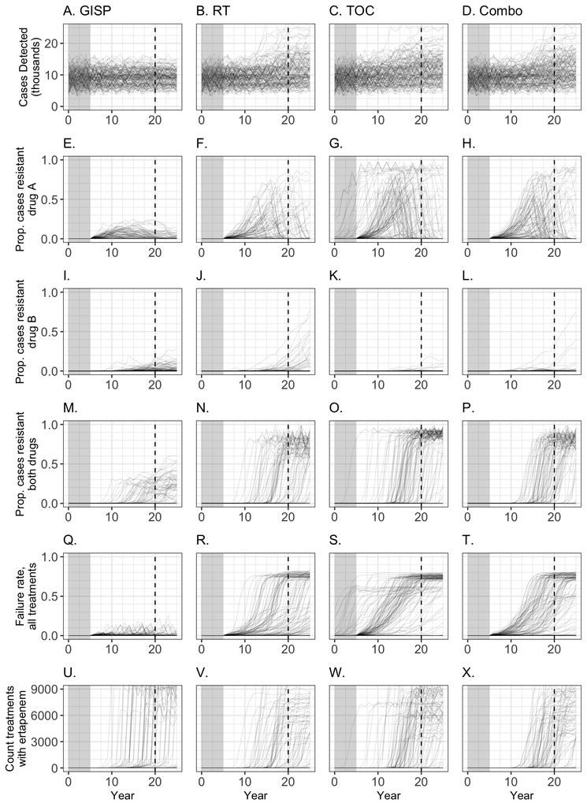

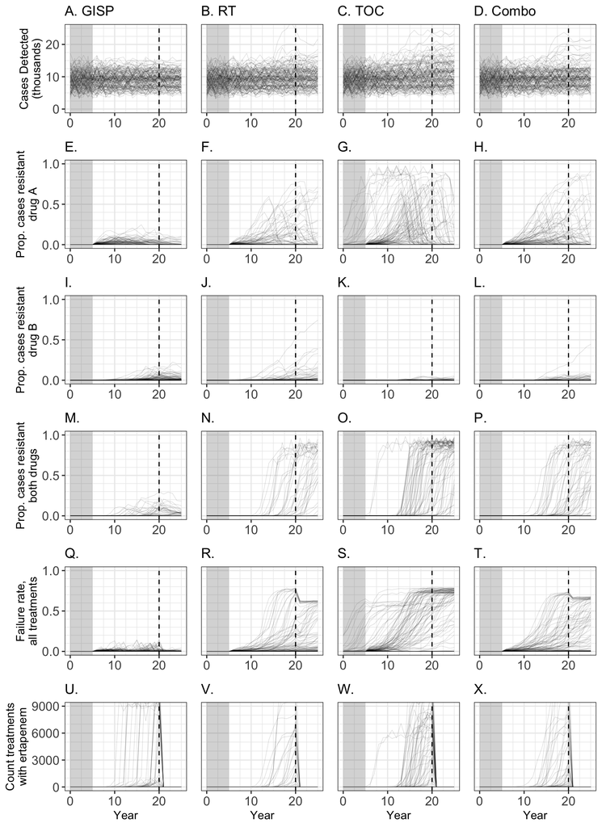

Figure. Trends in incidence and resistance when fitness costs were 1%for both strain resistant to drug A and strain resistant to drug B.

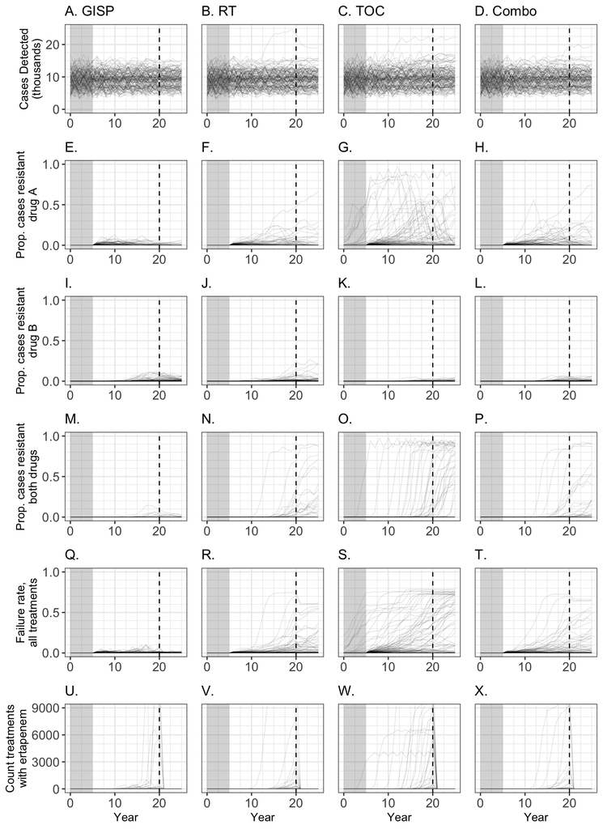

Figure. Trends in incidence and resistance when fitness costs were 2.5% for both strain resistant to drug A and strain resistant to drug B.

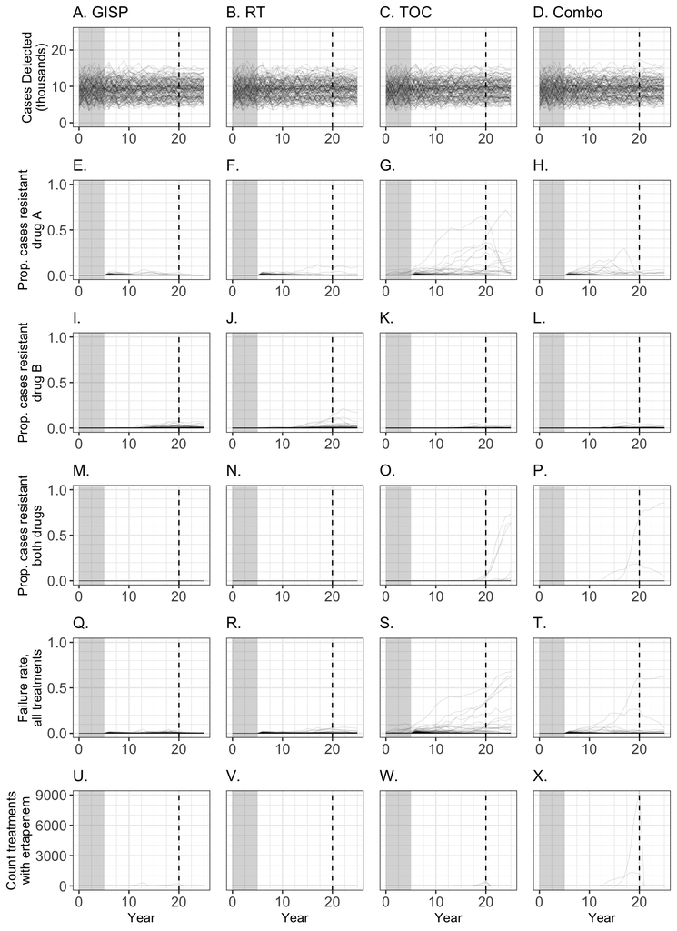

Figure. Trends in incidence and resistance when fitness costs were 5% for both strain resistant to drug A and strain resistant to drug B.

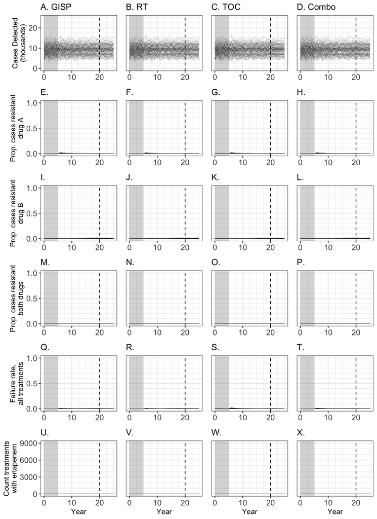

Figure. Trends in incidence and resistance when fitness costs were 10% for both strain resistant to drug A and strain resistant to drug B.

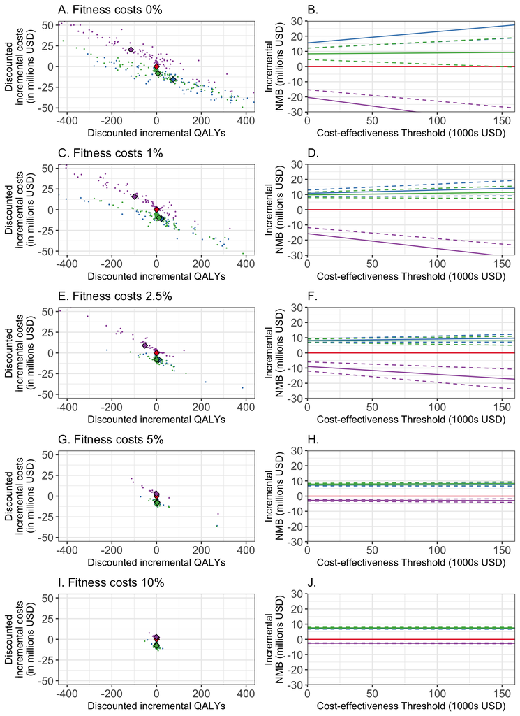